# Modelos de Regresión Robustos - Caso de estudio: Radiación trás el accidente de la Central Nuclear Fukushima

Flavia Felicioni y Clara Villalba

## Planteo del problema

Nuestro objetivo es crear un modelo lineal para explicar la disminución atraves del tiempo de los niveles de radiación del componente Cesio 137 en las zonas aledañas a la planta nuclear Fukushima luego del accidente nuclear ocasionado por el terremoto de magnitud 9,0 en el años 2011.

Como consecuencia de este accidente se liberó la mayor cantidad de radiación (principalmente de Cesio) al medio ambiente desde el accidente de Chernobyl, representando un riesgo de dosis de radiación muy significante para las personas y fauna local. Buena parte de las partículas radiactivas liberadas terminaron llegando a los ríos cercanos a la Central y fueron transportados hacia el mar. Asimismo el gobierno japonés realizó tareas de saneamiento y limpieza en zonas terrestres que contribuyeron a la reducción de partículas radiactivas que caían a los ríos.

Para este analisis nos basamos en el artículo “Dataset on the 6-year radiocesium transport in rivers near Fukushima Daiichi nuclear power plant” de la revista Scientific Data. [ Taniguchi, K., Onda, Y., Smith, H.G. et al. Dataset on the 6-year radiocesium transport in rivers near Fukushima Daiichi nuclear power plant. Sci Data 7, 433 (2020). DOI: https://doi.org/10.1038/s41597-020-00774-x]

En dicho artículo se proporcionan las mediciones de Cesio radiactivo (Cesio 137 y Cesio 134) ambos muy importantes para evaluar el impacto del accidente y el riesgo radiactivo en mediano-largo plazo. Se monitorearon en total 30 rios establecidos en un rango de 80 kms de la central nuclear. Se cuenta con la informacion de los sensores de dichas zonas para un periodo del 2011 a 2017.

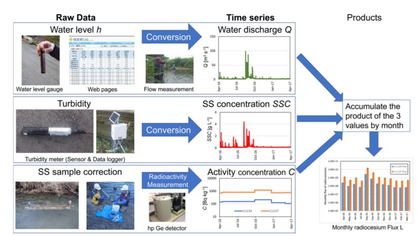

Imagen esquemática del cálculo de niveles de Cesio realizado en el estudio. Taniguchi, K., Onda, Y., Smith, H.G. et al. Dataset on the 6-year radiocesium transport in rivers near Fukushima Daiichi nuclear power plant. Sci Data 7, 433 (2020). https://doi.org/10.1038/s41597-020-00774-x

También se tomó como referencia el Apunte de Regresión Lineal de la Dra. María Eugenia Szretter Noste de la Carrera de Especialización en Estadística para Ciencias de la Salud, Universidad de Buenos Aires, 2017, disponibles en [**eea - campus datamining uba**](http://datamining.dc.uba.ar/campus/course/view.php?id=73)

Esta notebook y los datos utilizados estan disponibles para su consulta en https://github.com/ClaraOF/TP2EEA21

Cargamos las librerías que vamos a utilizar

```r
library(readr)
library(MASS)
library(tidyverse)
library(tidymodels)
library(ggplot2)
library(GGally)
library(RColorBrewer)
library(ggmosaic)
library(gridExtra)
#install.packages("predict3d")
library("predict3d")
```

## Preparación de los datos

Los datos que utilizaremos estan divididos en dos Datasets que contienen las mediciones de los siguientes períodos:

- DOI00020_data.csv: período 2011-2015
- DOI00014_data.csv: perodo 2015-2017

Levantamos ambos Datasets y renombramos algunas columnas

```r
setwd("C:/Users/clara.o.villalba/Documents/FACULTAD/EEA21/TP2")  #Establezco el Working Directory
df2 <- read_csv("DOI00014_data.csv")
df1 <- read_csv("DOI00020_data.csv")
names(df1)[28]<-"actividadCs137"
names(df2)[28]<-"actividadCs137"
names(df1)[29]<-"incerteza_actividadCs137"
names(df2)[29]<-"incerteza_actividadCs137"
names(df1)[33]<-"actividadCs134"
names(df2)[33]<-"actividadCs134"
names(df1)[34]<-"incerteza_actividadCs134"
names(df2)[34]<-"incerteza_actividadCs134"
names(df2)[39]<-"Correction_Periods"
```

Unimos ambos archivo y seleccionamos algunas variables de interés:

- *xyear*: el año. Este campo esta discretizado usando la siguiente formula: xyear=yyyy+(mm-1)/12+(dd-1)/365
- *LatDecimal*: latitud de la ubicacion donde se tomo la muestra. Este dato fue pasado a decimal usando la siguiente formula: LatDecimal=(LatD+LatM/60+LatS/3600)
- *LongDecimal*: longitud de la ubicacion donde se tomo la muestra. Este dato fue pasado a decimal usando la siguiente formula: LongDecimal=(LongD+LongM/60+LongS/3600)
- *altdep*: altura y profundidad del rio (unidad de medida metros)
- *actividadCs137*: cantidad de C137 detectada.
- *incerteza_actividadCs137*: error en la medición de CS137
- *actividadCs134*: cantidad de C134 detectada.
- *incerteza_actividadCs134*: error en la medición de CS134
- *name_river*: nombre del río de donde se saco la muestra.
- *Site_Number*: numero del sensor.

```r
c1<-colnames(df1)
c2<-colnames(df2)
columnas<-intersect(c1,c2)

df<-rbind(df1[,columnas],df2[,columnas])
rm(df1)
rm(df2)

df<-df %>% select(c("xyear","LatDecimal","LongDecimal","altdep","actividadCs137","incerteza_actividadCs137","actividadCs134","incerteza_actividadCs134","name_river","Site_Number"))
df$Site_Number<-factor(df$Site_Number)
```

Nuestra variable a predecir será el nivel de radiación del Cesio 137 (actividadCs137) campo al cual previamente le aplicamos logaritmo en base 10 al igual que lo hacen en el artículo de referencia. La unidad de medida de dicho campo es Becquerel / Kilogramos.

```r
df<- df %>% mutate(log_act_Cs137=log10(actividadCs137))
df<- df %>% mutate(log_act_Cs134=log10(actividadCs134))
```

Observemos un resumen de los datos

```r
glimpse(df)
```

```
Rows: 1,093
Columns: 12
$ xyear                    <dbl> 2011.488, 2011.530, 2011.552, 2011.566, 2011.583, 20~
$ LatDecimal               <dbl> 37.58556, 37.58556, 37.58556, 37.58556, 37.58556, 37~
$ LongDecimal              <dbl> 140.6922, 140.6922, 140.6922, 140.6922, 140.6922, 14~
$ altdep                   <dbl> 517.5, 517.5, 517.5, 517.5, 517.5, 517.5, 517.5, 517~
$ actividadCs137           <dbl> 48521, 38478, 9279, 24172, 55369, 25720, 33892, 3424~
$ incerteza_actividadCs137 <dbl> 1452, 1245, 557, 1060, 1112, 619, 1336, 645, 280, 10~
$ actividadCs134           <dbl> 45398, 31341, 8278, 22241, 45335, 22395, 27422, 2961~
$ incerteza_actividadCs134 <dbl> 1608, 1295, 621, 1184, 1436, 622, 1365, 820, 370, 12~
$ name_river               <chr> "Mizusakai", "Mizusakai", "Mizusakai", "Mizusakai", ~
$ Site_Number              <fct> 1, 1, 1, 1, 1, 1, 1, 1, 1, 1, 1, 1, 1, 1, 1, 1, 1, 1~
$ log_act_Cs137            <dbl> 4.685930, 4.585212, 3.967501, 4.383313, 4.743267, 4.~
$ log_act_Cs134            <dbl> 4.657037, 4.496113, 3.917925, 4.347154, 4.656434, 4.~
```

```r
df %>%
  head()
```

| xyear | LatDecimal | LongDecimal | altdep | actividadCs137 | incerteza_actividadCs137 | actividadCs134 | incerteza_actividadCs134 | name_river | Site_Number | log_act_Cs137 | log_act_Cs134 |
| --- | --- | --- | --- | --- | --- | --- | --- | --- | --- | --- | --- |
| 2011.488 | 37.58556 | 140.6922 | 517.5 | 48521 | 1452 | 45398 | 1608 | Mizusakai | 1 | 4.685930 | 4.657037 |
| 2011.530 | 37.58556 | 140.6922 | 517.5 | 38478 | 1245 | 31341 | 1295 | Mizusakai | 1 | 4.585212 | 4.496113 |
| 2011.552 | 37.58556 | 140.6922 | 517.5 | 9279 | 557 | 8278 | 621 | Mizusakai | 1 | 3.967501 | 3.917925 |
| 2011.566 | 37.58556 | 140.6922 | 517.5 | 24172 | 1060 | 22241 | 1184 | Mizusakai | 1 | 4.383313 | 4.347154 |
| 2011.583 | 37.58556 | 140.6922 | 517.5 | 55369 | 1112 | 45335 | 1436 | Mizusakai | 1 | 4.743267 | 4.656434 |
| 2011.605 | 37.58556 | 140.6922 | 517.5 | 25720 | 619 | 22395 | 622 | Mizusakai | 1 | 4.410271 | 4.350151 |

Podemos observar que el dataset tiene 1093 observaciones y 12 variables

A continuación, creamos un mapa navegable para visualizar la zona a analizar:

```r
## -----------------------   mapa navegable -------------------------------------
#install.packages("highcharter")
library(highcharter)
#
 tabla_sensores<-df %>% select(c(Site_Number,LatDecimal,LongDecimal)) %>% distinct()
#
 tags<-paste0("sensor_",tabla_sensores$Site_Number)
#
 tabla_sensores<-rbind(tabla_sensores,c(factor("CN"),37.421389, 141.0325)) #central nuclear
 tags<-c(unlist(tags),"CN")
#
#
 sensores <- data.frame(
   name = tags,
   lat = tabla_sensores$LatDecimal,
   lon = tabla_sensores$LongDecimal,
   z = seq(1,30)
 )
#
 hcmap("countries/jp/jp-all", showInLegend = FALSE) %>%
   hc_add_series(
     data = sensores,
     type = "mappoint",
     name = "Sensores",
     color= hex_to_rgba("darkred", alpha = 0.3),
     minSize = "1%",
     maxSize = "5%"
   ) %>%
  hc_mapNavigation(enabled = TRUE)
```

[interactive chart not shown]

Como mencionamos anteriormente, nuestra variable a predecir sera la radiacion del Cesio 137 (log_act_Cs137). Decidimos usar esa variable pues es la que tiene mayor tiempo de semidesintegración (Cs137 tarda 30 años y el 134 20 años).

En el archivo original contamos con la informacion de 30 sensores distintos. Para facilitar el análisis nos quedaremos con la información de los 6 sensores asociadas al Rio Abukuma el canal principal con salida al mar.

```r
#-------------------------- Rio Abukuma- Principal--------------------
df_abukuma<-filter(df, name_river == "Abukuma")
df_abukuma$Site_Number<-factor(df_abukuma$Site_Number)
unique(df_abukuma$Site_Number)
```

```
[1] 5  6  12 13 17 21
Levels: 5 6 12 13 17 21
```

```r
glimpse(df_abukuma)
```

```
Rows: 229
Columns: 12
$ xyear                    <dbl> 2011.527, 2011.549, 2011.566, 2011.605, 2011.624, 20~
$ LatDecimal               <dbl> 37.82861, 37.82861, 37.82861, 37.82861, 37.82861, 37~
$ LongDecimal              <dbl> 140.52, 140.52, 140.52, 140.52, 140.52, 140.52, 140.~
$ altdep                   <dbl> 49.5, 49.5, 49.5, 49.5, 49.5, 49.5, 49.5, 49.5, 49.5~
$ actividadCs137           <dbl> 55287, 30195, 40982, 32330, 38754, 32515, 21810, 308~
$ incerteza_actividadCs137 <dbl> 1801, 1848, 971, 427, 980, 829, 418, 1291, 1242, 141~
$ actividadCs134           <dbl> 52959, 30054, 36909, 28763, 31680, 27591, 19812, 270~
$ incerteza_actividadCs134 <dbl> 1898, 2108, 1088, 438, 1035, 1006, 570, 1651, 1525, ~
$ name_river               <chr> "Abukuma", "Abukuma", "Abukuma", "Abukuma", "Abukuma~
$ Site_Number              <fct> 5, 5, 5, 5, 5, 5, 5, 5, 5, 5, 5, 5, 5, 5, 5, 5, 5, 5~
$ log_act_Cs137            <dbl> 4.742623, 4.479935, 4.612593, 4.509606, 4.588317, 4.~
$ log_act_Cs134            <dbl> 4.723940, 4.477902, 4.567132, 4.458834, 4.500785, 4.~
```

Finalmente este archivo cuenta con 229 observaciones. Los 6 sensores asociadas al Rio Abukuma tienen los siguientes numeros identificatorios: 5, 6, 12, 13, 17, 21

Graficamos como fue la evolución de la actividad del CS137 en el Río Abukuma a través del tiempo.

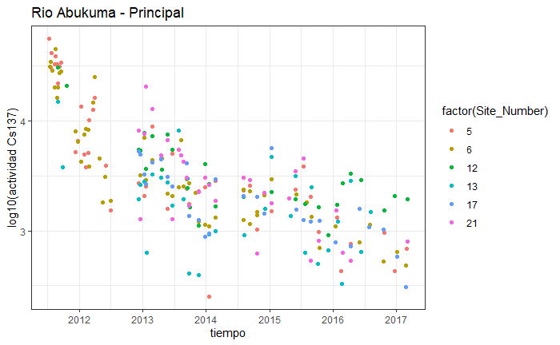

```r
g2 <- ggplot(df_abukuma , aes(xyear,(log_act_Cs137)))+
  geom_point(aes(color = factor(Site_Number)))+
  ggtitle("Rio Abukuma - Principal") +
  xlab("tiempo") + ylab("log10(actividad Cs137)")+
  theme_bw()
g2
```

En el grafico anterior podemos observar una disminucion de la actividad radiactiva con el paso del tiempo.

Veamos cómo es la correlación entre las variables numéricas.

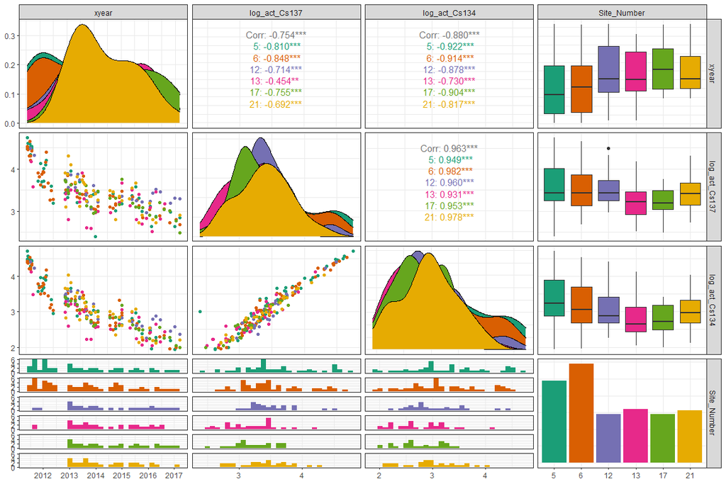

```r
# grafico correlaciones
g <- ggpairs(df_abukuma %>% select(c("xyear","log_act_Cs137","log_act_Cs134","Site_Number")), aes(color = factor(df_abukuma$Site_Number)))+
  theme(axis.text.x = element_text(angle = 90, hjust = 1), legend.position = "bottom") +
  theme_bw()

for(i in 1:g$nrow) {
  for(j in 1:g$ncol){
    g[i,j] <- g[i,j] +
      scale_fill_brewer(palette="Dark2") +
      scale_color_brewer(palette="Dark2")
  }
}
g
```

Respecto de nuestra variable a predecir, observamos:

- presenta una muy alta correlacion con la varaible de radiacion CS134, lo cual es esperable.
- el año también esta muy correlacionado con ambas mediciones y de manera negativa lo que se condice con que la radiacion se va reduciendo en el tiempo.

## Modelo Múltiple Simple

Como nos interesa analizar la evolucion de la radiación del Cesio 137 a travez del tiempo, planteamos un modelo simple en donde solo utilizaremos el tiempo como variable predictora.

$Cs137 = \beta_0 + \beta_1x_{i1}$

Para facilitar el analisis solo tomaremos las mediciones de los sensores 6 y 17.

```r
#filtramos los datos de los sensores 6 y 17:
df_abukuma6_17<-filter(df_abukuma, Site_Number %in% c(6,17))
glimpse(df_abukuma6_17)
```

```
Rows: 88
Columns: 12
$ xyear                    <dbl> 2011.530, 2011.549, 2011.568, 2011.608, 2011.627, 20~
$ LatDecimal               <dbl> 38.09472, 38.09472, 38.09472, 38.09472, 38.09472, 38~
$ LongDecimal              <dbl> 140.8719, 140.8719, 140.8719, 140.8719, 140.8719, 14~
$ altdep                   <dbl> 3.5, 3.5, 3.5, 3.5, 3.5, 3.5, 3.5, 3.5, 3.5, 3.5, 3.~
$ actividadCs137           <dbl> 30939, 34450, 28331, 20209, 44393, 16155, 20127, 271~
$ incerteza_actividadCs137 <dbl> 1611, 1707, 1013, 629, 1996, 931, 686, 345, 1635, 43~
$ actividadCs134           <dbl> 24542, 26538, 23782, 16655, 34168, 17181, 15561, 231~
$ incerteza_actividadCs134 <dbl> 2324, 1720, 1014, 658, 2025, 1347, 849, 451, 1973, 4~
$ name_river               <chr> "Abukuma", "Abukuma", "Abukuma", "Abukuma", "Abukuma~
$ Site_Number              <fct> 6, 6, 6, 6, 6, 6, 6, 6, 6, 6, 6, 6, 6, 6, 6, 6, 6, 6~
$ log_act_Cs137            <dbl> 4.490506, 4.537189, 4.452262, 4.305545, 4.647314, 4.~
$ log_act_Cs134            <dbl> 4.389910, 4.423868, 4.376248, 4.221545, 4.533620, 4.~
```

Finalmente nos quedamos entonces con 88 observaciones.

Ajustamos este primer modelo con los datos mencionados:

```r
#definimos la formula
f1<-formula(log_act_Cs137 ~ xyear)
#ajustamos el modelo
modelo_1 <- lm(f1, data = df_abukuma6_17)
# Resumen del modelo
tidy_sc_r <- tidy(modelo_1, conf.int = TRUE)
tidy_sc_r
```

| term | estimate | std.error | statistic | p.value | conf.low | conf.high |
| --- | --- | --- | --- | --- | --- | --- |
| (Intercept) | 497.1539002 | 34.45158239 | 14.43051 | 0.000000000000000000000001085841 | 428.6664211 | 565.6413793 |
| xyear | -0.2451408 | 0.01710603 | -14.33067 | 0.000000000000000000000001658726 | -0.2791464 | -0.2111351 |

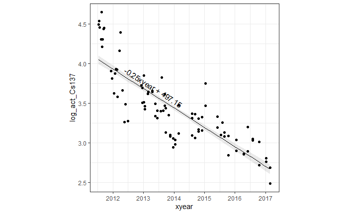

```r
#graficamos
predict3d::ggPredict(modelo_1,se=TRUE)
```

Podemos ver que:

- Teóricamente el valor del intercepto (497.1539002) es igual al valor esperado de radición para el año cero. Por este motivo este valor carece de interpretación práctica.
- El valor de β1^= -0.2451408 indica que por cada aumento de un año la radiación esperada se reduce en dicho valor.

Realizamos el diagnóstico del modelo

```r
glance(modelo_1)
```

| r.squared | adj.r.squared | sigma | statistic | p.value | df | logLik | AIC | BIC | deviance | df.residual | nobs |
| --- | --- | --- | --- | --- | --- | --- | --- | --- | --- | --- | --- |
| 0.7048406 | 0.7014085 | 0.2608009 | 205.368 | 0.000000000000000000000001658726 | 1 | -5.583218 | 17.16644 | 24.59845 | 5.84947 | 86 | 88 |

Observamos que el R-cuadrado es igual a 0.70 por lo tanto el modelo propuesto es un muy buen modelo para explicar la variacion de la radicacion del Cesio 137 atravez del tiempo.

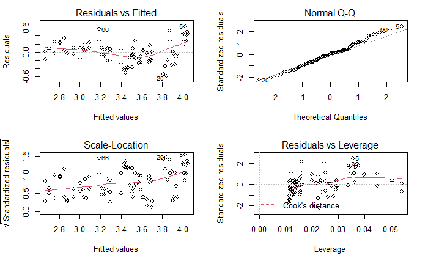

```r
#summary(modelo_2)
par(mfrow=c(2,2))
plot(modelo_1)
```

Sin embargo, obeservando en los graficos de residuos vemos que:

- **Residuos vs valores predichos:** Parece existir cierta estructura en los datos: hay una leve curvatura
- **Normal QQ plot**: los extremos no se ajustan a la distribución teórica
- **Residual vs leverage**: Existen algunos puntos con un mayor leverage pero no llegan a ser puntos influyentes.

Como el objetivo de este trabajo es mostrar un caso de aplicación de modelos robustos, decidimos agregar manualmente algunas observaciones influyentes.

Para ello luego de analizar los datos decidimos tomar observaciones del sensor 12 con fecha mayor a 2016, multiplicarlas por 1.30 y luego agregarlas al dataset que teniamos.

```r
#tomamos las observaciones del sensor 12
agregar<-df_abukuma[df_abukuma[, "Site_Number"] == 12 & df_abukuma[, "xyear"] > 2016.3,]
glimpse(agregar)
```

```
Rows: 4
Columns: 12
$ xyear                    <dbl> 2016.441, 2016.813, 2016.971, 2017.169
$ LatDecimal               <dbl> 37.59444, 37.59444, 37.59444, 37.59444
$ LongDecimal              <dbl> 140.4611, 140.4611, 140.4611, 140.4611
$ altdep                   <dbl> 189.7, 189.7, 189.7, 189.7
$ actividadCs137           <dbl> 2884, 1535, 2062, 1945
$ incerteza_actividadCs137 <dbl> 102, 41, 72, 123
$ actividadCs134           <dbl> 590, 284, 376, 236
$ incerteza_actividadCs134 <dbl> 48, 17, 38, 65
$ name_river               <chr> "Abukuma", "Abukuma", "Abukuma", "Abukuma"
$ Site_Number              <fct> 12, 12, 12, 12
$ log_act_Cs137            <dbl> 3.459995, 3.186108, 3.314289, 3.288920
$ log_act_Cs134            <dbl> 2.770852, 2.453318, 2.575188, 2.372912
```

```r
#son 4 las observaciones agregadas
#hacemos el calculo:
agregar$log_act_Cs137<-agregar$log_act_Cs137*1.30
#lo agregamos a nuestro datos originales:
df_abukuma6_17<-rbind(df_abukuma6_17,agregar)
glimpse(df_abukuma6_17)
```

```
Rows: 92
Columns: 12
$ xyear                    <dbl> 2011.530, 2011.549, 2011.568, 2011.608, 2011.627, 20~
$ LatDecimal               <dbl> 38.09472, 38.09472, 38.09472, 38.09472, 38.09472, 38~
$ LongDecimal              <dbl> 140.8719, 140.8719, 140.8719, 140.8719, 140.8719, 14~
$ altdep                   <dbl> 3.5, 3.5, 3.5, 3.5, 3.5, 3.5, 3.5, 3.5, 3.5, 3.5, 3.~
$ actividadCs137           <dbl> 30939, 34450, 28331, 20209, 44393, 16155, 20127, 271~
$ incerteza_actividadCs137 <dbl> 1611, 1707, 1013, 629, 1996, 931, 686, 345, 1635, 43~
$ actividadCs134           <dbl> 24542, 26538, 23782, 16655, 34168, 17181, 15561, 231~
$ incerteza_actividadCs134 <dbl> 2324, 1720, 1014, 658, 2025, 1347, 849, 451, 1973, 4~
$ name_river               <chr> "Abukuma", "Abukuma", "Abukuma", "Abukuma", "Abukuma~
$ Site_Number              <fct> 6, 6, 6, 6, 6, 6, 6, 6, 6, 6, 6, 6, 6, 6, 6, 6, 6, 6~
$ log_act_Cs137            <dbl> 4.490506, 4.537189, 4.452262, 4.305545, 4.647314, 4.~
$ log_act_Cs134            <dbl> 4.389910, 4.423868, 4.376248, 4.221545, 4.533620, 4.~
```

Como podemos observar se agregaron 4 nuevas observaciones.

Apliquemos el modelo_1 sobre estos nuevos datos:

```r
#definimos la formula
f1<-formula(log_act_Cs137 ~ xyear)
#ajustamos el modelo
modelo_1b <- lm(f1, data = df_abukuma6_17)
# Resumen del modelo
tidy_sc_r <- tidy(modelo_1b, conf.int = TRUE)
tidy_sc_r
```

| term | estimate | std.error | statistic | p.value | conf.low | conf.high |
| --- | --- | --- | --- | --- | --- | --- |
| (Intercept) | 367.2180942 | 49.17797987 | 7.467124 | 0.00000000005039868 | 269.5174537 | 464.918735 |
| xyear | -0.1805947 | 0.02441653 | -7.396412 | 0.00000000007019041 | -0.2291024 | -0.132087 |

```r
NA
```

Realizamos el diagnostico del modelo

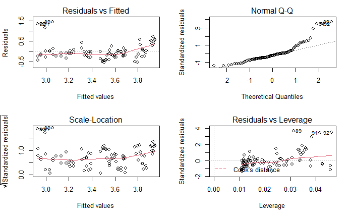

```r
par(mfrow=c(2,2))
plot(modelo_1b)
```

Con este nuevo dataset notamos la presencia de observaciones influyentes que arrastraron la recta hacia ellas tal como podemos apreciar en los siguientes gráficos. Es decir el modelo se ve influenciado por la presencia de estos datos.

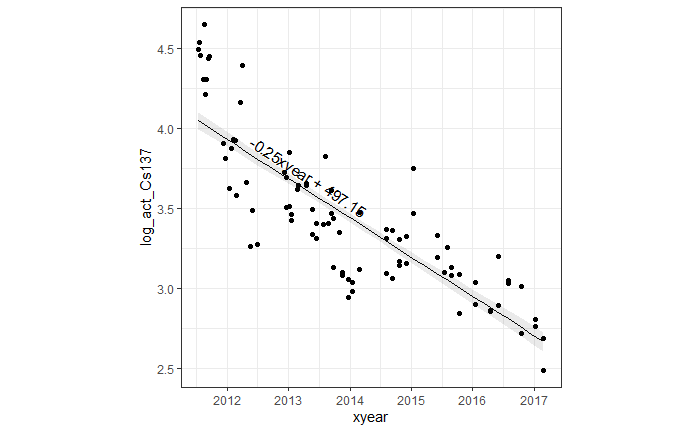

```r
#graficamos ambos modelos para comparar

predict3d::ggPredict(modelo_1,se=TRUE)
```

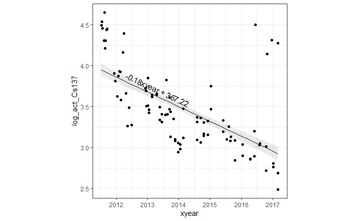

```r
predict3d::ggPredict(modelo_1b,se=TRUE)
```

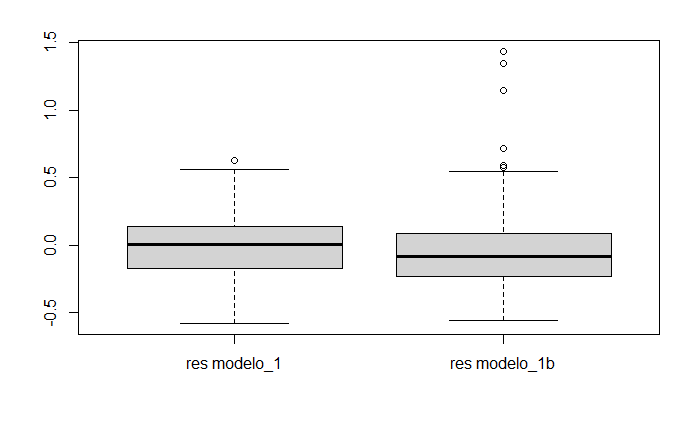

```r
boxplot(residuals(modelo_1),
residuals(modelo_1b),names=c("res modelo_1","res modelo_1b"))
```

Aplicaremos modelos robustos sobre este nuevo dataset

## Modelo Robusto

Ajustaremos 2 modelos:

- **lmrob**: es la implementación en R de un ajuste robusto usando MM-estimador de regresión. Usa el algoritmo M-S de Maronna and Yohai (2000) (Paquete robustbase)
- **rlm**: tambien usa un MM-estimador de regresión pero fue una de las primeras implemetaciones de modelos robustos. (Paquete MASS)

```r
library(robustbase)
modelo_lmrob <- lmrob(f1, data = df_abukuma6_17)
modelo_rlm <- rlm(f1, data = df_abukuma6_17)

# Resumen de los modelos
tidy_sc_lmrob <- tidy(modelo_lmrob, conf.int = TRUE)
tidy_sc_lmrob
```

| term | estimate | std.error | statistic | p.value | conf.low | conf.high |
| --- | --- | --- | --- | --- | --- | --- |
| (Intercept) | 482.8502475 | 43.23390413 | 11.16832 | 0.000000000000000001106207 | 398.1133525 | 567.5871425 |
| xyear | -0.2380415 | 0.02145618 | -11.09431 | 0.000000000000000001568740 | -0.2800949 | -0.1959882 |

```r
tidy_sc_rlm <- tidy(modelo_rlm, conf.int = TRUE)
tidy_sc_rlm
```

| term | estimate | std.error | statistic | conf.low | conf.high |
| --- | --- | --- | --- | --- | --- |
| (Intercept) | 441.8755468 | 36.19592670 | 12.20788 | 370.9328341 | 512.818260 |
| xyear | -0.2176906 | 0.01797103 | -12.11342 | -0.2529131 | -0.182468 |

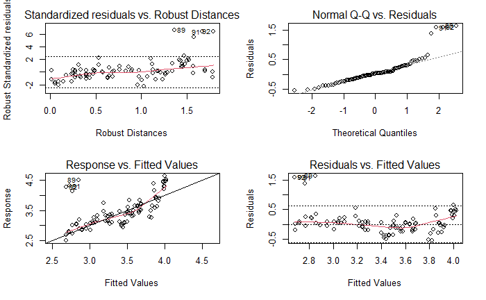

```r
par(mfrow=c(2,2))
plot(modelo_lmrob)
```

[figure not shown]

```r
par(mfrow=c(2,2))
```

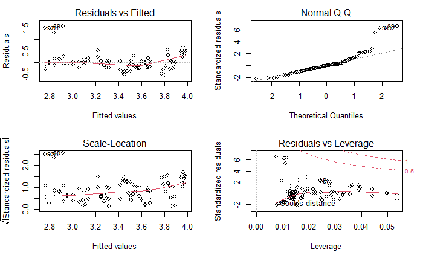

```r
plot(modelo_rlm)
```

```r
robpesos<-modelo_lmrob$rweights
robpesos
```

```
        1         2         3         4         5         6         7         8
0.7005774 0.6389594 0.7338589 0.8692333 0.4727759 0.9329433 0.8590806 0.7217153
        9        10        11        12        13        14        15        16
0.6993618 0.9993206 0.9824948 0.8885990 0.9992911 0.9971849 0.9972822 0.8767603
       17        18        19        20        21        22        23        24
0.8662652 0.6097880 0.9546108 0.5854975 0.8498490 0.6397061 0.9533588 0.9531195
       25        26        27        28        29        30        31        32
0.9438694 0.9999723 0.9954564 0.9117533 0.9088086 0.9717066 0.8739365 0.9802468
       33        34        35        36        37        38        39        40
0.9980144 0.9938383 0.9763366 0.7979071 0.7943925 0.7886428 0.8852302 0.9427237
       41        42        43        44        45        46        47        48
0.9911757 0.9373357 0.9879645 0.9845916 0.9913340 0.9831255 0.8885171 0.8881702
       49        50        51        52        53        54        55        56
0.9981047 0.9998813 0.9628838 0.9194361 0.9995411 0.9972242 0.9886078 0.9634009
       57        58        59        60        61        62        63        64
0.9830805 0.8114131 0.8135833 0.6703141 0.7250600 0.9922634 0.9994623 0.9941512
       65        66        67        68        69        70        71        72
0.9947417 0.5849043 0.9184674 0.9403301 0.9880051 0.9589331 0.9877643 0.9984023
       73        74        75        76        77        78        79        80
0.9985458 0.9211406 0.9964890 0.9880784 0.9999782 0.9864562 0.9986100 0.9978214
       81        82        83        84        85        86        87        88
0.9909966 0.9960967 0.9979646 0.8365578 0.9342631 0.9138442 0.9965109 0.9449012
       89        90        91        92
0.0000000 0.0000000 0.0000000 0.0000000
```

En la tabla anterior podemos observar que el peso que el ajuste robusto otorga a cada observación es prácticamente el mismo y casi uno, excepto para las últimas 4 observaciones (las que agregamos intencionalmente) que reciben peso cero, es decir no interviene en el ajuste.

### Graficamos los residuos

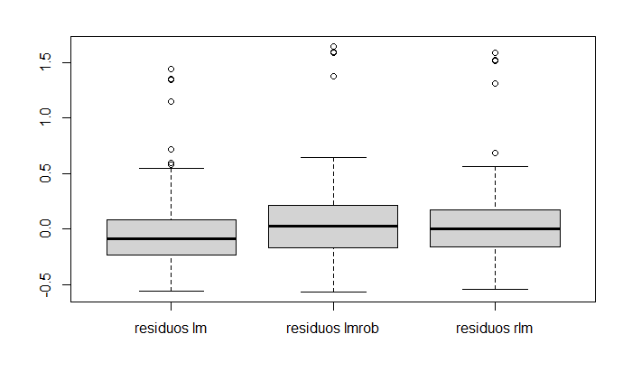

```r
library(robustbase)
#residuos
boxplot(residuals(modelo_1b),residuals(modelo_lmrob),
residuals(modelo_rlm),
names=c("residuos lm","residuos lmrob","residuos rlm"))
```

El ajuste de lm arrastra la recta hacia los datos atipicos enmascarando la presencia de algunos outlier. El ajuste del lmrob y rlm, al no dejarse influenciar por observaciones atípicas permiten identificar outliers al estudiar los residuos.

### Evaluacion de los modelos

```r
models <- list(modelo_inicial = modelo_1, modelo_perturbado = modelo_1b, modelo_lmrob = modelo_lmrob, modelo_rlm= modelo_rlm)
# calculamos las variables resumen
purrr::map_df(models, broom::tidy, .id = "model")
```

| model | term | estimate | std.error | statistic | p.value |
| --- | --- | --- | --- | --- | --- |
| modelo_inicial | (Intercept) | 497.1539002 | 34.45158239 | 14.430510 | 0.000000000000000000000001085841 |
| modelo_inicial | xyear | -0.2451408 | 0.01710603 | -14.330666 | 0.000000000000000000000001658726 |
| modelo_perturbado | (Intercept) | 367.2180942 | 49.17797987 | 7.467124 | 0.000000000050398676488824528481 |
| modelo_perturbado | xyear | -0.1805947 | 0.02441653 | -7.396412 | 0.000000000070190411546103441817 |
| modelo_lmrob | (Intercept) | 482.8502475 | 43.23390413 | 11.168324 | 0.000000000000000001106206974032 |
| modelo_lmrob | xyear | -0.2380415 | 0.02145618 | -11.094310 | 0.000000000000000001568739881177 |
| modelo_rlm | (Intercept) | 441.8755468 | 36.19592670 | 12.207880 | NA |
| modelo_rlm | xyear | -0.2176906 | 0.01797103 | -12.113415 | NA |

```r
# Aplicamos la función augment a los modelos
lista_predicciones = map(.x = models, .f = augment)
# Obtenemos el MAE para los  modelos
map_dfr(.x = lista_predicciones, .f = mae, truth = log_act_Cs137, estimate = .fitted, .id="modelo") %>% arrange(.estimate)
```

| modelo | .metric | .estimator | .estimate |
| --- | --- | --- | --- |
| modelo_inicial | mae | standard | 0.2019553 |
| modelo_rlm | mae | standard | 0.2563602 |
| modelo_lmrob | mae | standard | 0.2594488 |
| modelo_perturbado | mae | standard | 0.2716208 |

Se observa que los modelos robustos dan menor valor de MAE

Comparamos ahora graficamente las rectas ajustadas por ambos modelos robustos vs la recta no robusta:

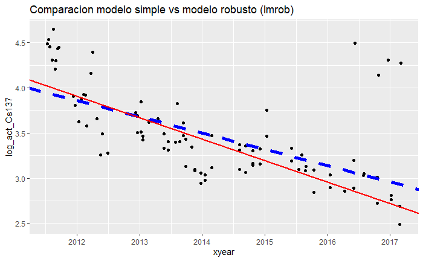

```r
ggplot(df_abukuma6_17,aes(xyear,log_act_Cs137)) + geom_point() + geom_abline(intercept = coef(modelo_1b)[1],slope = coef(modelo_1b)[2],col="blue",lty=2,lwd=2) +
geom_abline(intercept =modelo_lmrob$coefficients[1],slope = modelo_lmrob$coefficients[2],col="red",lty=1,lwd=1)+ labs(title = "Comparacion modelo simple vs modelo robusto (lmrob)")
```

La linea azul punteada representa al modelo lineal simple, observamos como su pendiente se ve influenciada por la presencial de observaciones atipicas. La linea roja es el modelo robusto ajustado con la funcion lmrob. Observamos como este segundo modelo no se ve influenciado.

Lo mismo podemos observar al comparlo con el modelo robusto ajustado con rlm.

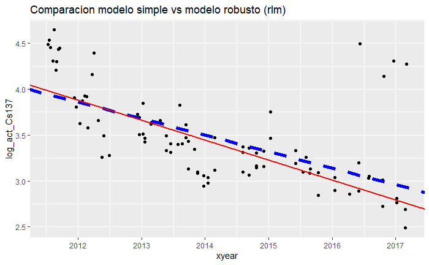

```r
ggplot(df_abukuma6_17,aes(xyear,log_act_Cs137)) + geom_point() + geom_abline(intercept = coef(modelo_1b)[1],slope = coef(modelo_1b)[2],col="blue",lty=2,lwd=2) +
geom_abline(intercept =modelo_rlm$coefficients[1],slope = modelo_rlm$coefficients[2],col="red",lty=1,lwd=1)+ labs(title = "Comparacion modelo simple vs modelo robusto (rlm)")
```

## Conclusiones

Si bien es posible explicar el problema planteado mediante un modelo lineal simple usando la recta de mínimos cuadrados, vimos que esta es muy sensible a la presencia de valoress atípicos. Esto lo comprobamos al agregar nuevas observaciones atípicas en el dataset que luego influenciaron notablemente al modelo inicial. En particular utilizamos dos implementacion de R que usan MM estimadores de regresión con las que pudimos evidenciar que le fueron asignados un peso igual a cero a las observaciones influyentes para que no intervengan en el ajuste. Concluimos entonces la importancia de hacer un ajuste robusto a los datos.